# NeuroBeat: Validation-Locked and Energy-Accounted Spiking Networks for Inter-Patient Ventricular Ectopic Beat Detection

Valerio Merlini

July 2026

Independent researcher  
Contact: valerio@covenance.ai  
Code, weights, and live dashboard: github.com/Talch87/neuro-beat and talch87.github.io/neuro-beat

## Abstract

**Problem.** Spiking neural networks (SNNs) are attractive for always-on cardiac monitoring because event-driven computation maps onto low-power neuromorphic hardware. Yet much of the SNN-ECG literature reports accuracy under protocols that inflate it (intra-patient splits, test-set-selected thresholds) and rarely reports the per-inference compute that motivates the approach.

**Approach.** We present NeuroBeat, a deliberately simple leaky-integrate-and-fire network for ventricular ectopic beat (VEB) detection, evaluated under a conservative protocol: a patient-disjoint inter-patient split (MIT-BIH DS1 to DS2), an operating point fit only on a DS1 validation holdout and then frozen for all test data, an explicit per-beat synaptic-operation (SynOps) budget, and frozen cross-database testing on two external databases.

**Result.** No single operating point reaches both high sensitivity and high precision (VEB sensitivity 0.894 at PPV 0.490, or 0.857 at 0.679), consistent with calibration variance under a small holdout. A gated-ensemble cascade, in which a sparse high-recall screener gates a three-seed confirmer on the roughly 27% of beats it flags, reaches VEB sensitivity 0.923 at PPV 0.616 on DS2 within 23,385 SynOps/beat and holds sensitivity at or above 0.90 across DS2, SVDB, and INCART under one frozen operating point. A patient-level bootstrap gives wide intervals (sensitivity 0.850 to 0.976, PPV 0.355 to 0.814), the honest uncertainty for 22 test patients; with a standard R-peak detector instead of annotations, end-to-end detection falls modestly to 0.884 / 0.593.

**Limitations.** SynOps is a compute proxy, not measured energy, and stronger non-spiking baselines match or beat the cascade on accuracy, so the spiking model’s case rests on per-beat operation count rather than accuracy. Single-lead supraventricular (SVEB) detection is an unresolved negative result. The contribution is a validation-locked, energy-accounted evaluation pattern and a cascade that improves the sensitivity/PPV/energy tradeoff, positioning the method as a candidate low-power VEB screening component, not a diagnostic system.

## 1. Introduction

Long-term ambulatory ECG is increasingly recorded by wearable and patch devices that must operate for days on a small battery. Ventricular ectopic beats are clinically meaningful: their frequency and patterning (for example couplets and non-sustained ventricular runs) are used in risk stratification, and reliable beat labelling underpins Holter reporting. A detector intended for continuous, on-device operation therefore has two coupled requirements: it must be sensitive, because missed ventricular beats are the costly error, and it must be inexpensive per beat, because energy determines battery life and thermal envelope.

Spiking networks are a candidate for this regime. They compute with sparse binary events, and on neuromorphic substrates the dominant cost is the number of synaptic operations actually triggered by spikes rather than a fixed clocked cost per layer. This has motivated a body of SNN-ECG work. Our reading of that literature, consistent with a recent systematic review [Silva2025], is that two recurring issues limit how far its accuracy numbers can be trusted for deployment.

First, evaluation is frequently optimistic. Under an intra-patient split, beats from the same patient appear in both training and test sets, so the model can exploit patient-specific morphology that a device deployed on a new patient never observes; reported accuracy then overstates real inter-patient performance. Separately, selecting the decision threshold (or per-class bias) on the test set leaks label information that is unavailable at deployment time, again inflating the headline metric. Neither practice is exotic; both are common enough that cross-study comparison is unreliable [Silva2025].

Second, energy is usually not accounted for. The stated reason to use an SNN is efficiency, yet many reports give only accuracy or parameter counts, with no per-inference operation budget against which efficiency could be judged.

The contribution of this paper is therefore not a novel architecture. The network is intentionally small and conventional. The contribution is evaluation discipline and an energy-accounted deployment framing: an operating point that is locked on validation data and never touched on test data, an explicit SynOps budget applied to every configuration, frozen cross-database testing, and a gated cascade that improves the sensitivity/PPV/energy tradeoff within that budget. We also report, rather than hide, a clear negative result for supraventricular beats on a single lead.

**Contributions.**

1. **A validation-locked inter-patient protocol.** We adopt the de Chazal DS1/DS2 patient-disjoint split [deChazal2004], hold out three DS1 records as a patient-disjoint validation set, fit the operating point only on that holdout, and freeze it for DS2 and all external data. No reported test number participates in selecting the operating point on the split it is reported on (Section 6).
2. **An explicit per-beat SynOps budget.** We define a per-beat synaptic-operation count (Section 5.4), report it for every configuration, and hold each to a fixed 25,000 SynOps/beat budget.
3. **Frozen cross-database validation.** The single frozen operating point is applied unchanged to two databases the model never trained on (SVDB, INCART), quantifying transfer under distribution shift.
4. **A gated-ensemble cascade within budget.** A sparse screener on every beat gates a small ensemble confirmer on flagged beats, reaching VEB sensitivity 0.923 at PPV 0.616 within 23,385 SynOps/beat, which no single-stage model in our sweep achieves.
5. **A negative result for single-lead SVEB.** Under the same protocol, single-lead supraventricular detection does not reach usable precision, and we document why and how it fails rather than tuning it to a misleading number.

## 2. Related Work

**(a) ECG arrhythmia classification and inter-patient evaluation.** The ANSI/AAMI EC57 standard [AAMI-EC57] defines the five heartbeat classes and the sensitivity/PPV reporting convention used throughout this literature. de Chazal et al. [deChazal2004] introduced the patient-disjoint DS1/DS2 partition of the 44 non-paced MIT-BIH records (about 50,000 beats per set) that has become the reference inter-patient benchmark. Many subsequent methods report higher raw accuracy than we do, but a substantial share do so under intra-patient splits or with test-set-selected thresholds; the systematic review of Silva et al. [Silva2025] documents that few studies simultaneously satisfy inter-patient partitioning, AAMI compliance, and embedded feasibility. We do not claim to beat the strongest reported numbers on raw accuracy; we claim comparability under a stricter, leakage-controlled protocol with an energy budget.

**(b) Low-power and embedded ECG inference.** A parallel line of work targets resource-constrained deployment through quantized and compact convolutional or temporal-convolutional models, pruning, and microcontroller implementations. These approaches report MACs, memory footprint, or measured microcontroller energy. They are the natural non-spiking comparison point for efficiency claims; we include convolutional, recurrent, temporal-convolutional, residual-CNN, gradient-boosted-tree, and SVM baselines, plus a weight-only int8 CNN, under the identical protocol (Section 7.8).

**(c) Spiking and neuromorphic ECG.** SNN-ECG methods report competitive MIT-BIH accuracy using delta-modulation encoding of the ECG and its derivatives [SNN-ECG-BSPC2021], spike-driven processors for wearable ECG [Chu2022], hardware/software co-design [SparrowSNN2024], and axonal-delay models [AxonalDelays2025]. Our count-pooled delta encoding over signal orders is in this family. We differ in evaluation rather than in mechanism: we report validation- locked inter-patient results with an explicit SynOps budget, frozen cross-database transfer, and a documented single-lead SVEB failure.

**(d) Cascaded and gated inference.** Two-stage screener/confirmer and energy-gated designs are established elsewhere for trading average compute against accuracy. We use the pattern narrowly: to make an ensemble-grade confirmer affordable on average by invoking it only on candidates a cheap screener flags.

**(e) Evaluation hygiene and reproducibility.** Our protocol choices follow the recommendations surveyed in [Silva2025]. We additionally release code, frozen weights, per-seed logs, and a public results page so that every reported number is regenerable.

## 3. Data

**MIT-BIH Arrhythmia Database (primary).** 48 two-lead ambulatory records sampled at 360 Hz. Annotated beats are mapped to the five AAMI classes: N (normal), S (supraventricular ectopic, SVEB), V (ventricular ectopic, VEB), F (fusion of normal and ventricular), and Q (unknown/paced). We use the de Chazal patient-disjoint split [deChazal2004]: DS1 for training and DS2 for test, with no patient in both. From DS1 we hold out records 201, 207, and 223 as a patient-disjoint validation set used only for operating-point selection. Beat counts are given in Table 1.

**External databases (test-only).** The MIT-BIH Supraventricular Arrhythmia Database (SVDB, 128 Hz) [SVDB] and the St. Petersburg INCART 12-lead Arrhythmia Database (INCART, 257 Hz) [INCART]. These are used exclusively for frozen cross-database testing; no external beat enters training or operating-point selection for the VEB models.

**Preprocessing and resampling.** External signals are resampled to 360 Hz with polyphase resampling (`scipy.signal.resample_poly`, applied to the ratio reduced by its greatest common divisor), and annotation sample indices are rescaled by the same factor. Lead selection is fixed a priori: MIT-BIH and SVDB use lead 0; INCART uses lead II (index 1). We apply no per-record adaptive filtering or denoising beyond resampling, so that the reported transfer reflects the raw morphology difference across databases.

**Beat segmentation and RR features.** Each beat is a fixed window of 256 samples (about 0.71 s at 360 Hz) centred on the annotated R-peak; we use provided annotations and do not run a separate detector, so results are conditional on accurate R-peak locations (Section 9). For each beat we compute three RR-interval features (previous RR, following RR, and their ratio). RR features are standardized using training-set statistics only, and the same statistics are applied unchanged to validation, test, and external data.

**Table 1. Beat counts by class (after segmentation).**

| Split | Total | N | SVEB (S) | VEB (V) | F | Q |
| --- | --- | --- | --- | --- | --- | --- |
| DS1 train | 44,573 | 40,624 | 636 | 2,907 | 398 | 8 |
| DS1 val (201/207/223) | 6,427 | 5,222 | 308 | 881 | 16 | 0 |
| DS2 test | 49,693 | 44,241 | 1,837 | 3,220 | 388 | 7 |
| SVDB (external) | 184,520 | 162,281 | 12,196 | 9,941 | 23 | 79 |
| INCART (external) | 175,811 | 153,621 | 1,959 | 20,006 | 219 | 6 |

*(All counts, including the DS1-train row, are generated by the final segmentation pipeline used for every experiment in this paper: a beat is included only when it carries a valid AAMI class label and a full 256-sample window fits within the record. The VEB and SVEB minorities are the quantities that matter for the class-weighted objective.)*

## 4. Figures

Figures 1 to 7 are rendered from the locked results and included below (sources in `paper/figures/`). All figures are external image files; none is embedded as inline base64 data.

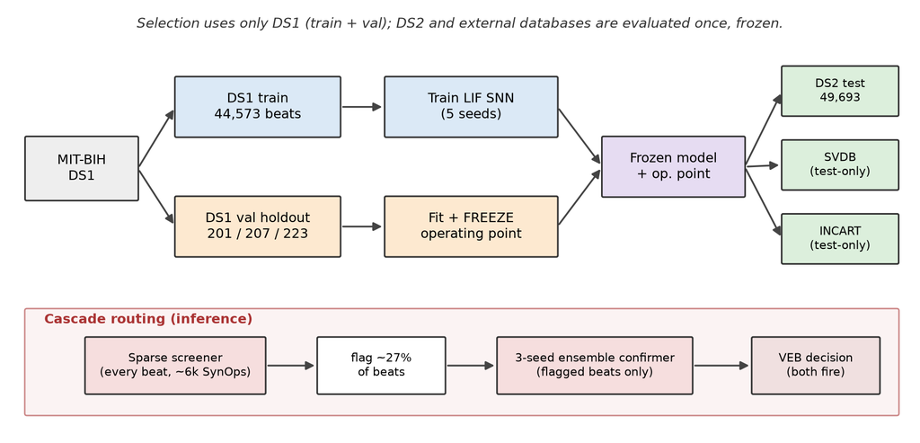

Figure 1

**Figure 1. Protocol and no-leakage design.** DS1 is split into a training set and a patient-disjoint validation holdout (records 201, 207, 223). The operating point is selected only on the validation holdout and then frozen. The frozen model is applied once to DS2 and, unchanged, to the external SVDB and INCART databases. The lower band shows cascade routing at inference (sparse screener on every beat; ensemble confirmer only on flagged beats). No test or external data participates in model or threshold selection.

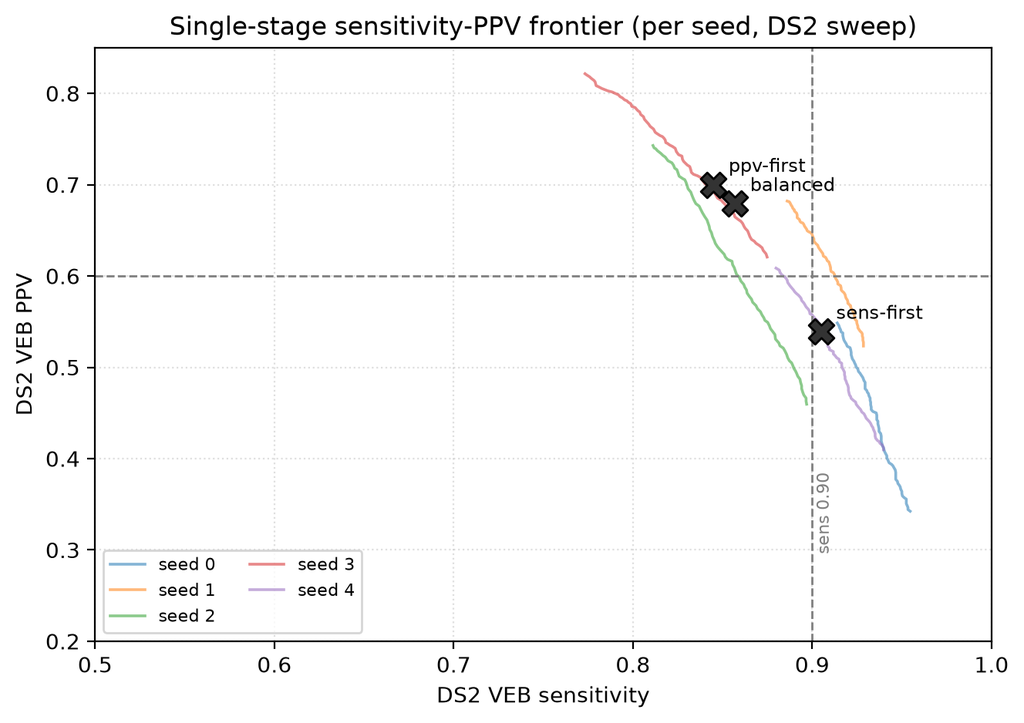

Figure 2

**Figure 2. Single-stage sensitivity-PPV frontier.** DS2 VEB PPV versus sensitivity for single-stage models, one curve per seed (DS2 threshold sweep), with the three validation-locked operating points marked and the 0.90 and 0.60 target lines. No single operating point reaches both sensitivity at or above 0.90 and PPV at or above 0.60 reliably across seeds.

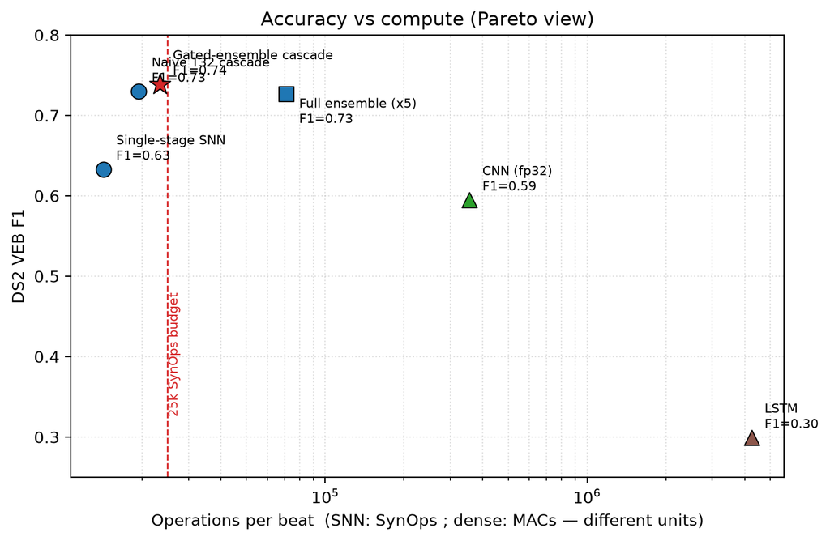

Figure 3

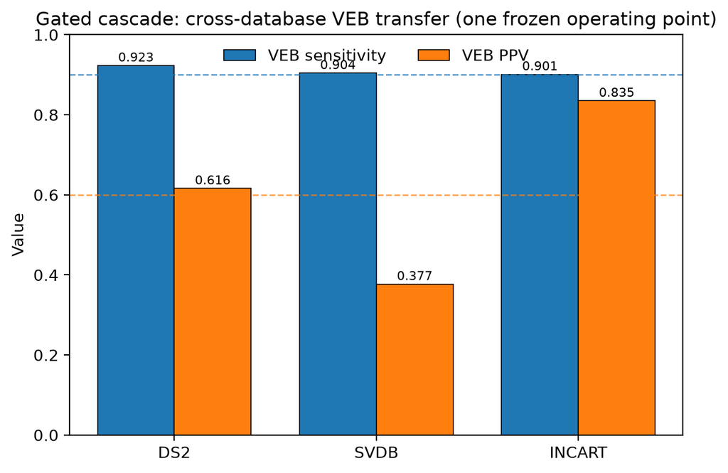

Figure 4

**Figure 4. Cross-database transfer.** VEB sensitivity and PPV for the frozen gated cascade on DS2, SVDB, and INCART, with the 0.90 and 0.60 target lines. VEB sensitivity stays at or above 0.90 on all three databases under one frozen operating point, while PPV varies with class prevalence.

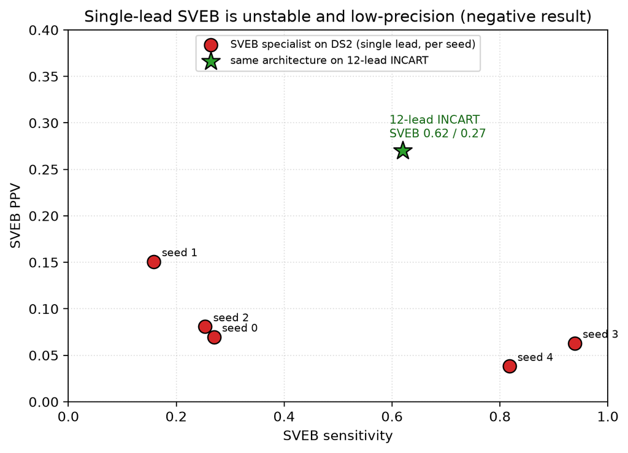

Figure 5

**Figure 5. Single-lead SVEB negative result.** DS2 SVEB sensitivity versus PPV per seed for the SVEB specialist (single lead), contrasted with the same specialist’s SVEB detection on 12-lead INCART. INCART supraventricular beats were part of this specialist’s augmented training set, so the INCART point is an in-domain, diagnostic reference, not external validation (Section 7.9). Single-lead SVEB is unstable and low-precision; the same specialist separates SVEB more readily when more lead information is available in-domain.

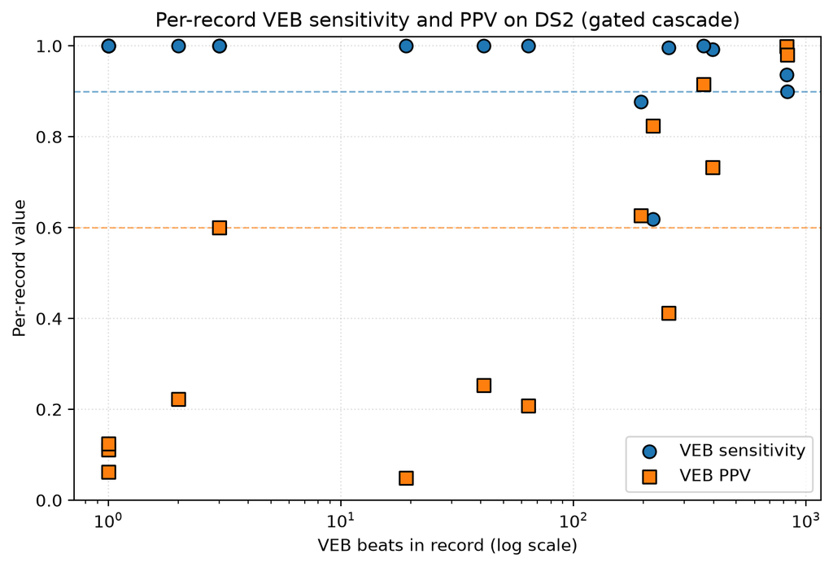

Figure 6

**Figure 6. Per-record robustness on DS2.** Per-record VEB sensitivity (circles) and PPV (squares) on DS2 for the frozen gated cascade, versus the record’s VEB count (log scale). Dashed lines mark the 0.90 sensitivity and 0.60 PPV targets. Only records with at least one VEB beat are shown. Sensitivity is high and stable on the high-VEB records except record 213; PPV is dispersed and falls well below target on several low-VEB records.

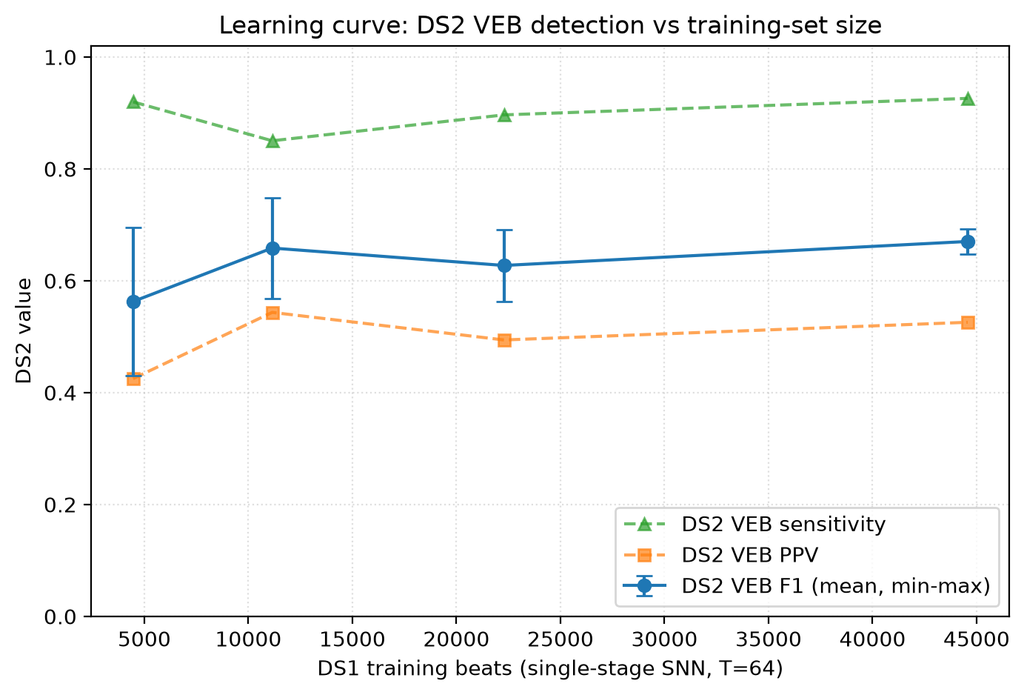

Figure 7

**Figure 7. Training-set-size learning curve.** DS2 VEB F1 (mean with min-max band), sensitivity, and PPV versus DS1 training beats for the single-stage model (T = 64, 2 seeds per point). In this limited two-seed diagnostic sweep, additional DS1 data appeared to narrow seed variance more than raise mean accuracy.

## 5. Methods

### 5.1 Spike encoding

Each 256-sample beat window is converted to a spike tensor by count-pooled delta encoding. For each signal order in the set `orders` (order 0 is the signal, order 1 its first difference), threshold crossings of magnitude theta = 0.12 (in normalized signal units) are accumulated into T time bins, producing two channels (rising and falling crossings) per order. With `orders = [0, 1]` this yields 2 x |orders| = 4 input channels over T timesteps. Because crossings are pooled by count into bins, the total number of input spikes over a beat is approximately conserved as T varies; increasing T redistributes the same spikes into finer bins rather than creating more of them (Section 8).

### 5.2 Network

The classifier is a two-layer LIF network. A linear map `fc1` projects the 4 input channels to H = 128 hidden LIF units; a linear map `fc2` projects hidden spikes to 5 class logits. The three RR features are projected once, through a separate dense map, into the hidden state (they are not re-injected at every timestep). The readout accumulates the output-layer membrane potential over T timesteps. Training uses surrogate-gradient backpropagation-through-time (snnTorch [Eshraghian2023], following [Neftci2019]) with the Adam optimizer, learning rate 4e-3, 100 epochs, batch size 512, and class weights scaled as the square root of inverse class frequency to counter imbalance. Unless stated otherwise the single-stage model uses T = 64.

### 5.3 Operating point selection

The network emits 5 logits; the decision adds a fixed per-class bias vector `b = [0, b_S, b_V, b_F, b_Q]` and takes the argmax, with `b_F` and `b_Q` set to a large negative constant (-12) that strongly disfavours the fusion and unknown classes, whose support in DS1 is too small to calibrate. This penalty makes those predictions rare rather than impossible; a small residual of beats with extreme logits still land there (Section 7.5), but they do not affect the VEB-versus-rest decision. The two free parameters `(b_S, b_V)` are selected by grid search on the validation holdout only, and then frozen. We define three selection strategies:

- **sens-first:** maximize validation VEB PPV subject to validation VEB sensitivity at or above 0.90;
- **ppv-first:** maximize validation VEB sensitivity subject to validation VEB PPV at or above 0.60;
- **balanced:** maximize validation VEB F1.

When a strategy’s constraint is infeasible on validation for a given seed, we report that seed as infeasible rather than substituting a degenerate maximum- sensitivity point. The single-stage NeuroBeat-VEB uses sens-first, because missing ventricular beats is the more costly error; we also report the full frontier so the tradeoff is explicit.

### 5.4 Energy proxy: SynOps per beat

We report a per-beat synaptic-operation count, defined as the number of accumulate operations triggered by spikes across the forward pass:

`SynOps = (sum over T of input_spikes) * H + (sum over T of hidden_spikes) * C + n_RR * H`,

where H = 128, C = 5, n_RR = 3, and `input_spikes` / `hidden_spikes` are the per-timestep active-unit counts. The first term (input to hidden) dominates and is encoding-dependent, which is why sparse, low-order input matters more than T. This proxy counts the accumulate operations a neuromorphic core performs; it excludes membrane-state updates, on-chip memory movement, the encoding and sensor front end, and any host overhead. It is therefore a compute proxy and not a measured energy figure (Sections 8 and 9). The budget throughout is 25,000 SynOps/beat.

**On the choice of 25,000 SynOps/beat.** This budget is a fixed design constraint we set before the final locked evaluation, not a measured device figure and not a clinically validated energy threshold. It is an exploratory, deployment-inspired target chosen to make the design problem non-trivial in both directions: it sits below the cost of running the full five-seed ensemble on every beat (about 71,000 SynOps/beat, Section 7.7), so “ensemble everything” is deliberately out of budget and accuracy must instead be earned through sparsity and gating; and it sits comfortably above the cheapest useful single-stage model (about 14,000 SynOps/beat), so the budget is not satisfied by default. Because every configuration in the paper is held to the same number, the budget functions as a common yardstick for comparing designs rather than as a guarantee about any particular chip. As a rough sense of scale only, at roughly 100,000 beats per day a 25,000-SynOp/beat detector performs on the order of a few billion spike-triggered accumulates per day; we give this for intuition and do not translate it into battery life, which depends on the hardware factors enumerated in Section 9.

### 5.5 Two-stage gated-ensemble cascade

A single model cannot reach both target thresholds at one operating point (Section 7.1). We therefore route inference through two stages:

- **Screener (every beat).** A deliberately sparse LIF network (T = 32, H = 64, encoding threshold 0.18, `orders = [0, 1]`), with its operating point fit on validation for high VEB recall. Its sparsity, not its shorter T, is what makes it cheap (Section 8): higher threshold and fewer hidden units reduce spike counts, whereas reducing T alone would not (Section 5.1).
- **Confirmer (flagged beats only).** A three-seed ensemble of the T = 64 models already trained for the single-stage study, combined by logit averaging. It runs only on beats the screener flags. A beat is declared VEB if and only if both the screener and the ensemble confirmer fire.

Both operating points are fit on validation only (screener recall target 0.97; confirmer maximizes cascade VEB PPV subject to cascade VEB sensitivity at or above 0.90 on validation), then frozen. Average energy is

`SynOps(screener) + flag_rate * K * SynOps(one confirmer member on flagged beats)`,

with K = 3. Because the flag rate is small, the heavier confirmer contributes little on average. The confirmer members’ SynOps are measured on the flagged (ectopic-enriched) beats, which are more active and therefore more expensive per beat than an average DS2 beat; we use that higher figure rather than the DS2-wide average, so the reported energy is not optimistic.

### 5.6 Seeds and model selection

Each configuration is trained with 5 seeds. For the single-stage frozen artifact, the seed is chosen by validation VEB F1 among seeds that satisfy the sens-first validation constraint, never by any DS2 or external number. For the cascade, the confirmer uses seeds 0 to 2; we report robustness to this choice in Section 7.3.

### 5.7 Hyperparameter selection and locking

For transparency about what was tuned and what was not: the encoding and architecture settings were fixed during exploratory development on DS1 and its validation holdout, guided by validation VEB F1 and SynOps, before the final locked evaluation. This applies to the single-stage settings (T = 64, H = 128, encoding threshold 0.12, orders [0, 1]), the screener settings (T = 32, H = 64, threshold 0.18), the three-seed confirmer, the 25,000-SynOps budget, and the choice of DS1 records 201, 207, and 223 as the validation holdout. This exploration was informal rather than an exhaustive grid search, and we do not claim these values are optimal; several of them (in particular H, the number of confirmer seeds, and the exact encoding thresholds) were set to reasonable values and not swept to convergence. A systematic sweep could plausibly improve the operating points and is left as future work.

What we do guarantee is the locking discipline. Once these settings were fixed, all operating points (single-stage and both cascade stages) were fit only on the DS1 validation holdout, and every number reported on DS2, SVDB, and INCART was produced by evaluating the resulting frozen artifacts against test sets that played no role in any selection (Section 6). The distinction we ask the reader to keep is between the architecture and hyperparameters, which were set during development and may be improvable, and the operating point and test evaluation, which are strictly locked and are the basis for every headline claim.

## 6. Evaluation protocol (no-leakage statement)

To state precisely what is and is not controlled:

1. The operating point (per-class biases), seed selection, decision threshold, and early-stopping decisions are fit only on the DS1 validation holdout, never on DS2, SVDB, or INCART. This is enforced in code: the selection routines see only validation logits.
2. All operating points (single-stage and both cascade stages) are selected only on the DS1 validation holdout (records 201, 207, 223), which is patient-disjoint from DS1 training.
3. SVDB and INCART are test-only. No external beat enters training or operating- point selection for the VEB models. Every cross-database number uses the same frozen operating point selected on DS1 validation.
4. Final reported artifacts and operating points were frozen before the final reported test tables were generated, and no test table was revised afterward to improve a number. We claim leakage-free operating-point and seed selection (points 1 to 3), not a fully blinded research process: the architecture and hyperparameters (Section 5.7) were set during exploratory development that was not blind to DS2, as is normal for method development. The guarantee is therefore that no reported operating point or seed was tuned on a test set, not that the process never observed DS2.

The one deliberate exception is the SVEB specialist (Section 7.9), which by design adds SVDB and INCART beats to training as an augmentation study; its DS2 test set remains untouched, and we flag its non-standard training explicitly. Because that specialist trains on SVDB and INCART, its SVDB and INCART numbers are in-domain and diagnostic, not external validation, and we label them as such (Section 7.9).

## 7. Results

All results use 5 training seeds. We report seed mean with [min, max] where a distribution exists, and 95% bootstrap confidence intervals (2,000 resamples over DS2 beats) for the headline cascade. DS2 contains 3,220 VEB beats out of 49,693 (Table 1), so a one-point change in sensitivity corresponds to about 32 beats.

### 7.1 Single-stage VEB detection

DS2 VEB detection under each validation-fit strategy (5 seeds), with SynOps/beat, is given in Table 2.

**Table 2. Single-stage DS2 VEB detection under each validation-fit operating-point strategy (5 seeds); seed mean with [min, max].**

| Operating point | VEB sensitivity | VEB PPV | F1 | SynOps/beat |
| --- | --- | --- | --- | --- |
| sens-first | 0.905 [0.878, 0.928] | 0.539 [0.490, 0.627] | 0.68 | about 14,300 |
| balanced | 0.857 [0.790, 0.912] | 0.679 [0.517, 0.780] | 0.76 | about 14,300 |
| ppv-first | 0.845 [0.771, 0.888] | 0.700 [0.583, 0.791] | 0.77 | about 14,300 |

A single operating point buys sensitivity or precision, not both: at sensitivity near 0.90 the PPV is about 0.54, and reaching PPV near 0.68 costs roughly 4 to 7 points of sensitivity. All single-stage configurations sit under the SynOps budget. Note that the balanced point has a higher F1 (0.76) than the cascade below (0.74): the cascade is not F1-optimal, it is selected to satisfy both clinical thresholds (sensitivity at or above 0.90 and PPV at or above 0.60) jointly, which the balanced point does not (its sensitivity is 0.857).

**Frontier (Figure 2).** Sweeping the VEB decision threshold on DS2 (an oracle sweep, shown only to characterize what is achievable, not as an operating point), the DS2 VEB PPV attainable at each sensitivity level spans, across the 5 seeds, the ranges in Table 3.

**Table 3. DS2 VEB PPV attainable at each sensitivity level under an oracle DS2 threshold sweep (range across 5 seeds). Shown to characterize what is achievable, not used as an operating point.**

| Sensitivity floor | 0.80 | 0.85 | 0.90 | 0.92 |
| --- | --- | --- | --- | --- |
| VEB PPV (range) | 0.57 to 0.78 | 0.57 to 0.69 | 0.56 to 0.65 | 0.48 to 0.57 |

Two of the five seeds cannot exceed 0.90 sensitivity on DS2 even at the oracle threshold, and no seed offers a single point at both sensitivity at or above 0.90 and PPV at or above 0.60 with margin. This motivates the cascade.

### 7.2 Cross-database generalization (single-stage)

A note on Table 2 versus Table 4, which report different quantities. Table 2 gives 5-seed means (sens-first: 0.905 / 0.539 on DS2). Table 4 reports the single frozen artifact selected for cross-database testing, chosen by validation VEB F1 among the sens-first-feasible seeds (Section 5.6); that artifact scored 0.894 / 0.490 on DS2. The frozen single-stage model (sens-first, fit on DS1 validation) applied unchanged is reported in Table 4.

**Table 4. Frozen single-stage cross-database VEB detection (one operating point fit on DS1 validation, applied unchanged to all three databases).**

| Database | Beats | VEB beats | VEB sensitivity | VEB PPV |
| --- | --- | --- | --- | --- |
| MIT-BIH DS2 | 49,693 | 3,220 | 0.894 | 0.490 |
| MIT-BIH SVDB | 184,520 | 9,941 | 0.892 | 0.361 |
| INCART | 175,811 | 20,006 | 0.880 | 0.736 |

VEB sensitivity holds in a narrow band (0.88 to 0.89) across three databases with different patients, leads, and original sampling rates, under one frozen operating point. PPV varies with class prevalence: it is lower on the supraventricular-dense SVDB (more non-VEB beats resembling VEB) and higher on the VEB-dense INCART. This is the expected behaviour of a fixed threshold under prevalence shift and is why we report sensitivity and PPV separately rather than a single accuracy figure.

### 7.3 Two-stage gated-ensemble cascade

The frozen cascade (screener recall target 0.97; confirmer fit for cascade PPV subject to cascade sensitivity at or above 0.90; both on validation only) is reported in Table 5.

**Table 5. Frozen gated-ensemble cascade cross-database VEB detection (both stages’ operating points fit on DS1 validation, then frozen).**

| Database | Beats | VEB beats | VEB sensitivity | VEB PPV | Flag rate |
| --- | --- | --- | --- | --- | --- |
| MIT-BIH DS2 | 49,693 | 3,220 | 0.923 | 0.616 | 0.271 |
| MIT-BIH SVDB | 184,520 | 9,941 | 0.904 | 0.377 | 0.345 |
| INCART | 175,811 | 20,006 | 0.901 | 0.835 | 0.241 |

We report two bootstrap intervals for the DS2 point estimates. A beat-level bootstrap (resampling beats independently, 2,000 resamples) gives sensitivity [0.914, 0.932] and PPV [0.602, 0.630]. A patient-level bootstrap (resampling the 22 DS2 records with replacement, which respects within-record correlation) gives much wider intervals: sensitivity [0.850, 0.976] and PPV [0.355, 0.814]. The gap between the two is large because VEB beats are concentrated in a minority of records, so a few patients dominate the estimate. The patient-level interval is the honest one to quote: the point estimates meet the targets on DS2’s specific patient composition, but per-patient behaviour varies substantially, and a wider prospective evaluation would be needed to tighten this. Average energy on DS2 is `5,987 + 0.271 * 3 * 21,433 = 23,385` SynOps/beat, within the 25,000 budget. Robustness to the confirmer composition: ensembles of K in {2, 3, 5} members and different 3-member subsets all give DS2 sensitivity at or above 0.90 at PPV between 0.59 and 0.64.

### 7.4 Per-record robustness

Aggregate DS2 metrics can hide the fact that ventricular beats are unevenly distributed across patients: two records (200 and 233) hold 1,656 of the 3,220 DS2 VEB beats (51%), so the headline sensitivity is effectively an average dominated by a few patients. Because a deployed device sees one patient at a time, per-record behaviour is the more deployment-relevant view. Table 6 gives the frozen cascade’s per-record VEB result for the 16 DS2 records that contain at least one VEB beat; Figure 6 plots the same per-record sensitivity and PPV against each record’s VEB count.

**Table 6. Per-record DS2 VEB detection (frozen gated cascade), for the 16 records with at least one VEB beat, sorted by VEB count.** TP/FN/FP are beat counts; sensitivity = TP/(TP+FN); PPV = TP/(TP+FP).

| Record | VEB beats | TP | FN | FP | Sensitivity | PPV |
| --- | --- | --- | --- | --- | --- | --- |
| 233 | 830 | 746 | 84 | 15 | 0.899 | 0.980 |
| 200 | 826 | 774 | 52 | 1 | 0.937 | 0.999 |
| 221 | 396 | 393 | 3 | 143 | 0.992 | 0.733 |
| 228 | 362 | 362 | 0 | 33 | 1.000 | 0.916 |
| 214 | 256 | 255 | 1 | 364 | 0.996 | 0.412 |
| 213 | 220 | 136 | 84 | 29 | 0.618 | 0.824 |
| 210 | 195 | 171 | 24 | 102 | 0.877 | 0.626 |
| 219 | 64 | 64 | 0 | 243 | 1.000 | 0.208 |
| 105 | 41 | 41 | 0 | 121 | 1.000 | 0.253 |
| 202 | 19 | 19 | 0 | 369 | 1.000 | 0.049 |
| 123 | 3 | 3 | 0 | 2 | 1.000 | 0.600 |
| 234 | 3 | 3 | 0 | 2 | 1.000 | 0.600 |
| 231 | 2 | 2 | 0 | 7 | 1.000 | 0.222 |
| 100 | 1 | 1 | 0 | 8 | 1.000 | 0.111 |
| 111 | 1 | 1 | 0 | 7 | 1.000 | 0.125 |
| 121 | 1 | 1 | 0 | 15 | 1.000 | 0.062 |

The six remaining DS2 records contain no VEB beats and so contribute only false positives: 389 in total, which is 21% of all 1,850 DS2 false positives. Record 222 alone emits 252 and record 113 emits 116.

**Interpretation.** Three patterns bear on how much weight the headline deserves. (i) Sensitivity is carried by the two largest records: 200 (0.937) and 233 (0.899) supply half the VEB beats between them, so the aggregate 0.923 would move materially if either behaved differently. (ii) One record is genuinely weak: record 213 has 220 VEB beats at sensitivity 0.618 and alone accounts for 84 of the 248 total missed beats (34%), a concentration that a beat-pooled metric obscures. (iii) PPV is highly non-uniform, ranging from about 0.05 to 0.999 across records; it is dragged down by a handful of records that emit many false positives relative to their VEB count (202, 214, 219, 105) and by the six VEB-free records. The headline PPV of 0.616 is therefore a prevalence-weighted average, not a value the detector attains on a typical single patient. This per-record dispersion is the concrete reason the patient-level bootstrap interval (Section 7.3) is so much wider than the beat-level one, and it is why we do not present the aggregate as a per-patient guarantee.

### 7.5 Error composition

To show which classes the detector confuses with VEB, Table 7 gives the VEB-versus-rest confusion for the frozen cascade on all three databases, with each false positive attributed to the true AAMI class of the beat that produced it. Table 8 gives the full five-class AAMI confusion for the single-stage model on DS2.

**Table 7. VEB-versus-rest confusion for the frozen gated cascade, with false positives broken down by the true class of the beat.** TN is all correctly-rejected non-VEB beats.

| Database | TP | FN | FP | TN | FP: N | FP: SVEB | FP: F | FP: Q |
| --- | --- | --- | --- | --- | --- | --- | --- | --- |
| MIT-BIH DS2 | 2,972 | 248 | 1,850 | 44,623 | 1,610 | 227 | 9 | 4 |
| MIT-BIH SVDB | 8,990 | 951 | 14,854 | 159,725 | 9,032 | 5,772 | 4 | 46 |
| INCART | 18,020 | 1,986 | 3,565 | 152,240 | 2,758 | 747 | 58 | 2 |

**Table 8. Single-stage DS2 five-class AAMI confusion matrix (frozen seed, sens-first operating point). Rows are true class, columns are predicted class.** The fusion (F) and unknown (Q) columns carry a large negative bias (Section 5.3), which strongly disfavours those predictions rather than forbidding them: 718 beats (1.4% of DS2) with extreme logits still fall into the F and Q columns. Because the task is VEB-versus-rest, these do not affect the VEB sensitivity or PPV.

| True Pred | N | SVEB | VEB | F | Q |
| --- | --- | --- | --- | --- | --- |
| N | 39,970 | 1,059 | 2,752 | 163 | 297 |
| SVEB | 1,154 | 222 | 221 | 0 | 240 |
| VEB | 284 | 55 | 2,880 | 1 | 0 |
| F | 347 | 0 | 24 | 17 | 0 |
| Q | 3 | 0 | 4 | 0 | 0 |

**What the errors are made of.** On DS2, false positives are dominated by normal beats (1,610 of 1,850, 87%), with a smaller but non-trivial supraventricular contribution (227, 12%); fusion and unknown contribute few VEB false positives. The single-stage matrix (Table 8) locates the same effect at the class level: the largest off-diagonal entry into the VEB column is N-to-VEB (2,752 beats), and 221 true SVEB beats are also read as VEB, consistent with single-lead morphological overlap between aberrantly-conducted supraventricular beats and ventricular ectopy. This overlap is what makes the SVDB PPV drop: on the supraventricular-dense SVDB, 5,772 of the 14,854 false positives (39%) are true SVEB beats, a far larger share than on DS2 (12%) or INCART (21%). The database with the most supraventricular beats produces the most SVEB-to-VEB confusion, so the lower SVDB PPV reflects class composition and single-lead ambiguity rather than a change in the detector’s ventricular behaviour, whose sensitivity is stable across all three databases (Section 7.3).

### 7.6 Statistical comparison

To test whether the cascade’s improvement over simpler configurations exceeds DS2 sampling noise, we use a paired record-level bootstrap: we resample the 22 DS2 records with replacement (2,000 resamples, respecting within-record correlation) and, on each resample, recompute the VEB F1 of two systems evaluated at their own frozen operating points, reporting the distribution of the paired difference. This is the record-level analogue of the interval in Section 7.3 and is stricter than a beat-level test because it does not treat beats from one patient as independent.

**Table 9. Paired record-level bootstrap on DS2 (2,000 resamples). Difference in VEB F1, gated cascade minus the comparator; positive favours the cascade.** “Cascade better” is the fraction of resamples in which the cascade’s F1 is higher.

| Comparison | Median F1 difference | 95% interval | Cascade better |
| --- | --- | --- | --- |
| Cascade vs single-stage (sens-first) | +0.103 | [+0.060, +0.142] | 100% |
| Cascade vs full 5-seed ensemble (every beat) | +0.013 | [-0.003, +0.027] | 95% |

The cascade’s advantage over the single-stage model is large and consistent: its F1 is higher in every one of the 2,000 record resamples and the interval excludes zero by a wide margin. Against the full five-seed ensemble that runs on every beat, the cascade is statistically indistinguishable in F1 (the interval includes zero) while using roughly a third of the operations (Section 7.7); the gating therefore buys the energy reduction at no measurable accuracy cost, which is the paper’s central efficiency claim. We run the same paired test against the non-spiking baselines in Section 7.8 (Table 12); to preview the honest outcome, the cascade is ahead of the CNN and linear SVM but behind the TCN, ResNet-lite, and gradient-boosted-tree baselines on DS2 F1, which we report rather than obscure. We give no p-values: at 22 patients the bootstrap interval and the fraction of resamples favouring each system are the summaries we consider defensible.

### 7.7 Accuracy-energy Pareto (Figure 3)

DS2 accuracy against per-beat compute for the main configurations is given in Table 10.

**Table 10. Accuracy-energy operating points on DS2. SNN rows are SynOps/beat; the dense-baseline comparison is in Table 11.**

| Model | DS2 sens / PPV | Compute/beat |
| --- | --- | --- |
| Single-stage (sens-first) | 0.894 / 0.490 | 14,200 SynOps |
| Naive T32 cascade | 0.883 / 0.622 | 19,400 SynOps |
| Full 5-seed ensemble (every beat) | 0.932 / 0.595 | about 71,000 SynOps |
| Gated-ensemble cascade | 0.923 / 0.616 | 23,385 SynOps |

The full ensemble reaches the target corner but costs about five forward passes and exceeds the budget. The gated cascade recovers most of that accuracy within budget by running the ensemble only on flagged beats. The naive T32 cascade is a cautionary point: it costs more than the single-stage model, because a shorter network is not a cheaper one under count-pooled encoding (Section 8).

### 7.8 Non-spiking baselines on the same split

We train 1-D CNN and LSTM baselines under the identical protocol: same DS1 train, same beat-plus-RR inputs, same validation-locked sens-first operating point, same frozen DS2 test, 5 seeds (Table 11).

**Table 11. Non-spiking baselines under the identical validation-locked protocol. Operation units differ (SynOps vs MACs) and are not directly comparable, as discussed below.**

| Model | DS2 sens | DS2 PPV | Operations/beat | Params |
| --- | --- | --- | --- | --- |
| CNN (1-D, beat+RR) | 0.945 [0.926, 0.959] | 0.434 | 356k MACs | 2.9k |
| LSTM (beat+RR) | 0.940 [0.911, 0.974] | 0.178 | 4.26M MACs | 17.5k |
| SNN single-stage | 0.894 | 0.490 | 14.2k SynOps | 18k |
| SNN gated-ensemble | 0.923 | 0.616 | 23.4k SynOps | n/a |

Two observations. First, the dense baselines show the same sensitivity/precision tradeoff: under the sens-first operating point they reach high sensitivity (about 0.94) but low PPV (0.43 for the CNN, 0.18 for the LSTM), so the tradeoff is a property of single-lead VEB detection rather than of spiking networks. Second, on operation count the SNN is far lower: 14k to 23k SynOps versus 356k (CNN) and 4.26M (LSTM) MACs. We state this carefully. A SynOp (a spike-triggered accumulate) and a MAC (a multiply-accumulate) are not the same unit, and this comparison is an operation-count advantage under a proxy model, not a measured energy ratio. We add stronger baselines below (Table 12); measured microcontroller energy remains the key missing piece (Section 9).

Post-training int8 weight quantization of the CNN (per-tensor symmetric, weights only, activations left in float, 3 seeds) preserves DS2 VEB detection: fp32 0.951 / 0.417 versus int8 0.951 / 0.444 (sensitivity / PPV), with weight memory reduced from 11.6 kB to 3.1 kB. This is the fair embedded operating point for the dense baseline: the MAC count is unchanged (356k/beat), but an int8 MAC is materially cheaper and smaller than an fp32 MAC on typical microcontrollers. Quantization therefore closes part of the compute gap in energy-per-operation terms without changing the operation count, and a full int8 pipeline (quantized activations, with calibration) plus measured board energy is the natural next comparison (Section 9).

**Stronger baselines, and an honest ranking.** To avoid overstating the spiking model, we add stronger baselines under the identical validation-locked protocol: a compact temporal convolutional network (TCN), a ResNet-lite 1-D CNN, gradient-boosted trees on morphology-plus-RR features, and a linear SVM (Table 12). Each neural model is frozen at the seed with the best validation VEB F1; the classical models use a fixed seed and a validation-locked VEB-vs-rest threshold. The “cascade minus model” column is the paired record-level bootstrap difference in DS2 VEB F1 (the same test as Section 7.6); a negative value means the baseline beats the cascade.

**Table 12. Additional embedded baselines under the identical protocol (frozen single artifact), with the gated cascade as reference. F1 is the VEB F1 at the frozen operating point. “Cascade minus model” is the paired record-level bootstrap difference in DS2 VEB F1; negative means the baseline is more accurate than the cascade.**

| Model | DS2 VEB sens | DS2 VEB PPV | F1 | Operations/beat | Cascade minus model F1 [95% CI] |
| --- | --- | --- | --- | --- | --- |
| Gated cascade (reference) | 0.923 | 0.616 | 0.739 | about 23.4k SynOps | (reference) |
| TCN | 0.939 | 0.729 | 0.821 | about 1.02M MACs | -0.088 [-0.251, +0.082] |
| ResNet-lite | 0.910 | 0.761 | 0.829 | about 539k MACs | -0.089 [-0.188, +0.009] |
| Gradient-boosted trees | 0.974 | 0.678 | 0.800 | about 200 trees (depth 4) | -0.060 [-0.146, +0.019] |
| Linear SVM | 0.981 | 0.259 | 0.410 | 259 MACs | +0.314 [+0.163, +0.477] |

For the gradient-boosted trees and SVM we report model structure rather than an operation count: tree inference is dominated by branch, comparison, and memory-access operations rather than multiply-accumulates, so a fair embedded comparison of those models would require measured latency or energy, not an operation count. The result is a useful corrective. Three of these baselines reach higher DS2 VEB F1 than the gated cascade: the TCN (0.939 / 0.729), ResNet-lite (0.910 / 0.761), and gradient-boosted trees (0.974 / 0.678); the paired bootstrap puts the cascade ahead of them in only 14%, 3%, and 5% of record resamples, respectively. The cascade does clearly beat the higher-sensitivity, lower-precision models: the fp32 and int8 CNN (ahead in 98% and 97% of resamples) and the linear SVM (100%). We therefore do not claim the spiking cascade is the most accurate DS2 VEB detector; on accuracy alone, a gradient-boosted tree on morphology-plus-RR features and a compact TCN are both better. What separates the cascade is per-beat operation count: it runs at about 23,000 SynOps/beat, roughly 20 to 45 times below the TCN and ResNet-lite MAC counts, while the tree and SVM models are non-spiking and do not map onto neuromorphic hardware. Whether that operation-count gap translates into an energy advantage depends on measured hardware energy, which we do not yet have (Section 9); this comparison is exactly why we treat measured energy, not the SynOps proxy, as the decisive missing experiment, and why we confine the spiking contribution to the operation-count and neuromorphic-suitability axis rather than to accuracy. (The gradient-boosted-tree and SVM baselines use a binary VEB-vs-rest operating point, a slightly more favourable mechanism than the five-class bias used for the neural and spiking models; the TCN and ResNet-lite, which also beat the cascade, use the identical five-class mechanism.)

### 7.9 Supraventricular beats: a single-lead negative result

Supraventricular ectopic beats often differ from normal beats mainly in timing and subtle morphology, and DS1 contains few of them (Table 1). As an incidental output of the VEB model, DS2 SVEB sensitivity is about 0.13; adding supraventricular-rich SVDB to training raises it to about 0.24, and a higher-time-resolution variant to about 0.27, all still low.

We then trained a dedicated SVEB specialist (higher time resolution, SVDB and INCART added to training, an SVEB-first operating point, 5 seeds). It does not yield a usable detector (Table 13).

**Table 13. SVEB specialist on DS2 (non-standard training: SVDB and INCART added to training; see text). “Degraded” indicates the VEB class collapses at that regime.**

| Seed regime | DS2 SVEB sens | DS2 SVEB PPV | DS2 VEB sens |
| --- | --- | --- | --- |
| calibrated (seeds 0 to 2) | 0.16 to 0.27 | 0.07 to 0.15 | degraded |
| degenerate (seeds 3 to 4) | 0.82 to 0.94 | 0.04 to 0.06 | 0.18 to 0.24 |

The high-sensitivity seeds reach it only by flagging almost all beats as SVEB (PPV at or below 0.06), which collapses the ventricular class. DS2 SVEB PPV never exceeds about 0.15 at any operating point, and the outcome is unstable across seeds.

**On the INCART result: in-domain, not external validation.** The same specialist reaches SVEB sensitivity about 0.62 on 12-lead INCART. This must not be read as external validation: INCART supraventricular beats were part of this specialist’s augmented training set, so the INCART number is an in-domain, diagnostic observation. Read only as diagnostic, it is consistent with the limiting factor being available lead information rather than model capacity, since the 12-lead recording appears to separate supraventricular beats more readily; but because the beats are in-domain, it does not establish generalization and must not be interpreted as cross-database SVEB performance. (This is the one place in the paper where an external database enters training, and we confine it to this diagnostic role; the DS2 SVEB test set remains untouched.) We therefore treat single-lead SVEB as an open problem and, importantly, do not allow it to reshape the VEB operating point. Multi-lead input (MIT-BIH provides a second lead; supraventricular beats separate better on some leads) and richer, genuinely held-out SVEB validation data are the natural next steps (Section 9).

### 7.10 End-to-end detection with detected R-peaks

Every result so far assumes ground-truth R-peak locations. To test how far that assumption carries, we ran the frozen cascade on DS2 with beats segmented at DETECTED R-peaks and RR features recomputed from the detected-peak spacing (no annotations at inference), scoring VEB detection against the true labels so that a missed R-peak becomes an end-to-end false negative and a spurious detection an end-to-end false positive. We report two detectors: wfdb’s standard XQRS detector and the repository’s minimal static-threshold on-patch detector (Table 14).

**Table 14. End-to-end DS2 VEB detection with detected (not annotated) R-peaks. Beat sensitivity/PPV are for R-peak detection; the last two columns are the frozen cascade scored against true labels through each detector.**

| Detector | Beat sens | Beat PPV | End-to-end VEB sens | End-to-end VEB PPV |
| --- | --- | --- | --- | --- |
| Annotated R-peaks (reference) | 1.000 | 1.000 | 0.923 | 0.616 |
| XQRS (standard) | 0.997 | 0.999 | 0.884 | 0.593 |
| Minimal on-patch detector | 0.784 | 1.000 | 0.513 | 0.479 |

With a competent standard detector (XQRS, beat sensitivity 0.997), the end-to-end cost is modest: VEB sensitivity falls from 0.923 to 0.884 and PPV from 0.616 to 0.593. We state the practical consequence plainly: under detected R-peaks the cascade falls below the 0.90 sensitivity target that the annotation-based operating point meets, even though the degradation with XQRS is small. Of the 3,220 true VEBs, 126 (3.9%) are missed because XQRS places no peak on them, a higher rate than its 0.3% overall beat-miss rate and consistent with ventricular beats being harder to detect (wide, atypical QRS); the remainder of the drop is 247 detected-but-misclassified VEBs. The minimal on-patch detector tells the other half of the story: its beat sensitivity is only 0.784 and end-to-end VEB sensitivity collapses to 0.513. The R-peak stage is therefore a first-order determinant of end-to-end performance: paired with a competent detector the annotation-conditional headline degrades gracefully, but a weak detector is catastrophic, so detector choice cannot be treated as an afterthought.

### 7.11 Sensitivity to training-set size

To test whether the VEB result is limited by training-set size, we retrained the single-stage model (T = 64, the paper configuration) on stratified 10%, 25%, 50%, and 100% of DS1-train, fitting the sens-first operating point on DS1-val and reporting frozen DS2 VEB detection (2 seeds per point; Table 15, Figure 7). The data subset at a given fraction is fixed, so only the training-set size varies.

**Table 15. DS2 VEB detection versus DS1 training-set size (single-stage, T = 64, sens-first, 2 seeds; mean, with F1 min-max band).**

| DS1 train used | Train beats | VEB beats | DS2 sens | DS2 PPV | DS2 F1 [min, max] |
| --- | --- | --- | --- | --- | --- |
| 10% | 4,458 | 291 | 0.920 | 0.425 | 0.563 [0.431, 0.695] |
| 25% | 11,144 | 727 | 0.850 | 0.544 | 0.659 [0.569, 0.748] |
| 50% | 22,287 | 1,454 | 0.897 | 0.494 | 0.627 [0.563, 0.692] |
| 100% | 44,573 | 2,907 | 0.926 | 0.526 | 0.670 [0.648, 0.693] |

The curve is essentially flat. VEB sensitivity shows no upward trend across the range (0.85 to 0.93), so even a tenth of DS1 (291 VEB beats) reaches the sensitivity the full set reaches; the mean F1 rises from 10% to 25% of the data and then plateaus (0.659 at 25% versus 0.670 at 100%). What more data buys is not a higher mean but lower variance: the F1 min-max band narrows from [0.431, 0.695] at 10% to [0.648, 0.693] at 100%, consistent with the calibration-variance account of Sections 7.1 and 8. The single-stage VEB result is therefore saturated with respect to DS1 training-set size: more same-distribution MIT-BIH data would stabilize the operating point but is unlikely to raise accuracy, which points back to architecture, encoding, and single-lead information (Section 7.8) as the operative limits, not sample count.

## 8. Discussion

**(a) Honest evaluation lowers headline numbers but increases trust.** Freezing the operating point on validation rather than test, and reporting inter-patient rather than intra-patient results, lowers our headline metrics relative to test-tuned or intra-patient reports. The compensating evidence is stability under a fixed decision rule: with one frozen operating point, VEB sensitivity remained at or above 0.90 across three databases, while PPV varied by database, which a threshold tuned per test set would not demonstrate. We regard this frozen cross-database behaviour as the most decision-relevant result in the paper.

**(b) Energy-accounted models need explicit budgets.** Reporting SynOps for every configuration, and enforcing a fixed budget, changes which design choices look attractive. It is what exposes the naive cascade as a false economy and the full ensemble as over budget, and it is what makes the sparse-screener design necessary rather than incidental.

**(c) Time resolution is not the same as energy cost under count-pooled encoding.** Because count-pooling approximately conserves total input spikes across T, the dominant SynOps term is roughly independent of T in our measurements. Two consequences follow under this encoding: raising T can sharpen discrimination at little additional energy cost, and a shorter network is not necessarily a cheaper one. A screener is therefore made cheap by reducing channels, hidden units, or spike rate (via a higher threshold), which is how our screener is built.

**(d) The cascade is consistent with reducing a calibration-variance limit at low average cost.** The DS2 oracle frontier shows that sensitivity at or above 0.90 at PPV at or above 0.60 is attainable, yet single models calibrated on a small validation holdout land there only occasionally and vary across seeds. A small ensemble reduces model variance and appears to calibrate more stably, reaching 0.918 / 0.634 on DS2 for three members; gating it behind a sparse screener delivers comparable accuracy within budget, and the paired bootstrap (Section 7.6) confirms the cascade matches the full ensemble in F1 at a fraction of the operations.

**(e) VEB is usable but not best-in-class on accuracy; single-lead SVEB is not solved.** The VEB result is usable under a strict protocol and an energy budget, but we do not claim it is the most accurate detector: under the identical protocol a compact TCN, a ResNet-lite CNN, and gradient-boosted trees reach higher DS2 F1 (Section 7.8). The spiking model’s case rests on per-beat operation count and neuromorphic suitability, pending measured energy, not on accuracy leadership. The SVEB result is a clean negative under the same protocol, and we present it as such.

**Alternative explanations we cannot fully exclude.** The cross-database PPV differences could reflect annotation-convention differences between databases rather than only prevalence. The single-model seed variance could partly reflect optimization noise rather than only calibration; the ensemble would help in either case. We report both beat-level and patient-level bootstrap intervals (Section 7.3); the patient-level interval is much wider because a few records dominate the DS2 VEB count, and it is the interval we treat as the honest uncertainty.

## 9. Limitations

- **SynOps is an architecture-level compute proxy, not hardware energy.** The SynOps count is a property of the network and its spike statistics; it should be interpreted as a compute proxy and not as measured joules. Real energy on a device depends on the specific neuromorphic chip or microcontroller and its energy-per-operation, on-chip and off-chip memory movement (frequently the true bottleneck), the input-encoding pipeline, the compiler and runtime, the sensor front end and analog-to-digital conversion, the R-peak detection stage, and whether inference runs batched or streaming. We report no measured hardware energy, and the operation-count gap to the dense baselines (Section 7.8) is an operation-count difference under a proxy, not an energy ratio. Measuring end-to-end energy on both a microcontroller (for the quantized CNN) and a neuromorphic target (for the SNN) is the single most important addition for any hardware-energy claim and is our primary item of future work.
- **Retrospective public data only.** All data are curated public research databases with expert beat annotations. Performance on raw, artefact-laden device recordings is untested.
- **Small validation holdout.** Three DS1 records make single-model operating points noisy; the ensemble mitigates but does not remove this. A larger or cross-validated holdout is likely to tighten calibration. A training-set-size ablation (Section 7.11) shows that more training data narrows seed variance but does not raise DS2 accuracy, so this noise is a holdout-size and calibration effect rather than a training-data-volume effect.
- **Detection depends on the R-peak stage.** The headline numbers use provided annotations. An end-to-end ablation (Section 7.10) shows that swapping in a standard detector (XQRS) lowers VEB sensitivity/PPV modestly to 0.884 / 0.593, but a weak detector collapses them to 0.513 / 0.479. A deployable system must include a competent R-peak detector, and its errors, especially missed ventricular beats, propagate to the end-to-end result.
- **Prevalence-dependent PPV.** Cross-database PPV is sensitive to class composition, so PPV numbers should be read together with the beat counts.
- **Single lead.** Results use one lead; SVEB in particular appears to need more lead information.
- **Large between-patient variance.** With only 22 DS2 patients, a patient-level bootstrap gives wide intervals (VEB sensitivity 0.85 to 0.98, PPV 0.36 to 0.81). The point estimates hold for DS2’s composition, but per-patient behaviour varies substantially, so a larger prospective cohort is needed to tighten them.
- **No prospective or clinical-workflow validation, and no subgroup or demographic fairness analysis.** Nothing here has been validated in a deployment or against regulatory-grade endpoints.

## 10. Clinical and commercial relevance

The most credible near-term role for this work is as a low-power VEB screening component inside a larger pipeline: wearable or patch ECG, Holter-style ambulatory monitoring, remote patient monitoring, or a neuromorphic edge inference block that flags ventricular ectopy for downstream review. In such a role, high sensitivity at a controlled compute budget, with predictable cross-database behaviour, is the relevant property. A PPV around 0.6 may be compatible with a screening workflow in which flagged beats are reviewed downstream, but the acceptable false-positive burden depends on the clinical setting and is not established here.

We make no claim of diagnostic or product readiness, and the headline experiment deliberately isolates the classifier by assuming pre-annotated R-peak locations and clean, curated beats; Section 7.10 relaxes the first assumption and shows the end-to-end cost of the R-peak stage is modest with a standard detector and severe with a weak one. A deployable system would additionally require robust on-device R-peak detection, rejection of unreadable or noise-corrupted segments, motion-artifact handling, streaming (rather than whole-record batch) inference, an explicit policy for uncertain or borderline beats, patient-level summarization and reporting rather than per-beat labels, integration into a clinical workflow with defined alarm handling, measured energy on the target hardware, and quality-system, software-as-a-medical-device, and regulatory validation. NeuroBeat as evaluated here is therefore a candidate low-power component for such a pipeline, not a complete or cleared product.

## 11. Conclusion

NeuroBeat is a deliberately compact and conventional spiking network; its main contribution is not the architecture but the evaluation. Under a validation-locked inter-patient protocol and an explicit per-beat SynOps budget, a gated-ensemble cascade reaches 0.923 VEB sensitivity at 0.616 PPV on MIT-BIH DS2 within 23,385 SynOps/beat, and, under one frozen operating point, keeps VEB sensitivity at or above 0.90 on two unseen databases. The results come with clear boundaries: SynOps is a compute proxy and not measured energy; PPV varies with database class composition and is dispersed across patients, so a patient-level bootstrap gives wide intervals; single-lead supraventricular detection is reported as an unresolved negative result; and nothing here has been clinically validated. Within those boundaries, the useful output is a reusable pattern for reporting SNN-ECG work: lock the operating point on validation, account for per-beat compute, freeze cross-database tests, and report the per-patient and negative results rather than only the headline. We release the protocol, the SynOps budgeting, and all artifacts so that others can reuse and scrutinize them.

## 12. Code and data availability

- **Code:** github.com/Talch87/neuro-beat (AGPL-3.0 / commercial dual license).
- **Live results page:** talch87.github.io/neuro-beat.
- **Data:** all databases are public on PhysioNet: the MIT-BIH Arrhythmia Database [Moody2001, Goldberger2000], the MIT-BIH Supraventricular Arrhythmia Database [SVDB], and the St. Petersburg INCART 12-lead Arrhythmia Database [INCART]. No private or patient-identifiable data are used.
- **Frozen artifacts:** `models/neurobeat-veb-v1/` (single-stage weights and operating point, sparse screener, three confirmer members, gated-cascade configuration, model card).
- **Protocol and analysis harnesses:** `experiments/freeze_veb_v1.py` (single-stage; `--refit-only` re-tunes the operating point from cache), `experiments/gated_ensemble_veb.py` (cascade), `experiments/baselines_veb.py` (CNN/LSTM), `experiments/baselines_extra.py` (TCN, ResNet-lite, gradient-boosted trees, SVM, and the paired bootstrap of Table 12), `experiments/quantized_cnn.py` (int8 CNN), `experiments/stats_ci.py` (bootstrap confidence intervals), `experiments/error_analysis.py` (per-record Table 6, confusion Tables 7 and 8, and paired bootstrap Table 9), `experiments/end2end_rpeak.py` (detected-R-peak end-to-end ablation, Table 14), and `experiments/learning_curve.py` (training-set size ablation, Table 15 and Figure 7).
- All experiments use 5 seeds with the operating point fit on DS1 validation only; every table in this paper is regenerable from the released cache.

## Ethics statement

This study uses only publicly available, de-identified ECG databases distributed through PhysioNet (MIT-BIH Arrhythmia, MIT-BIH Supraventricular Arrhythmia, and St. Petersburg INCART). It involves no new human-subject data collection and no patient-identifiable information. The work is a retrospective, methodological evaluation and is not a clinical investigation.

## References

- **[AAMI-EC57]** ANSI/AAMI EC57. *Testing and Reporting Performance Results of Cardiac Rhythm and ST-Segment Measurement Algorithms.* Association for the Advancement of Medical Instrumentation.
- **[deChazal2004]** P. de Chazal, M. O’Dwyer, R. B. Reilly. “Automatic classification of heartbeats using ECG morphology and heartbeat interval features.” *IEEE Trans. Biomed. Eng.*, 51(7):1196–1206, 2004. doi:10.1109/TBME.2004.827359.
- **[Silva2025]** G. Silva, P. Silva, G. Moreira, V. Freitas, J. Gertrudes, E. Luz. “A Systematic Review of ECG Arrhythmia Classification: Adherence to Standards, Fair Evaluation, and Embedded Feasibility.” arXiv:2503.07276, 2025.
- **[Moody2001]** G. B. Moody, R. G. Mark. “The impact of the MIT-BIH Arrhythmia Database.” *IEEE Eng. Med. Biol. Mag.*, 20(3):45–50, 2001. doi:10.1109/51.932724.
- **[Goldberger2000]** A. L. Goldberger et al. “PhysioBank, PhysioToolkit, and PhysioNet.” *Circulation*, 101(23):e215–e220, 2000. doi:10.1161/01.CIR.101.23.e215.
- **[SVDB]** S. D. Greenwald. “Improved detection and classification of arrhythmias in noise-corrupted electrocardiograms using contextual information.” Ph.D. thesis, Harvard-MIT Division of Health Sciences and Technology, 1990. MIT-BIH Supraventricular Arrhythmia Database, PhysioNet. doi:10.13026/C2V30W.
- **[INCART]** V. Tihonenko, A. Khaustov, S. Ivanov, A. Rivin. St. Petersburg INCART 12-lead Arrhythmia Database, PhysioNet. doi:10.13026/C2V88N.
- **[Neftci2019]** E. O. Neftci, H. Mostafa, F. Zenke. “Surrogate Gradient Learning in Spiking Neural Networks.” *IEEE Signal Process. Mag.*, 36(6):51–63, 2019. doi:10.1109/MSP.2019.2931595.
- **[Eshraghian2023]** J. K. Eshraghian et al. “Training Spiking Neural Networks Using Lessons From Deep Learning.” *Proc. IEEE*, 111(9):1016–1054, 2023. doi:10.1109/JPROC.2023.3308088.
- **[Davies2018]** M. Davies et al. “Loihi: A Neuromorphic Manycore Processor with On-Chip Learning.” *IEEE Micro*, 38(1):82–99, 2018. doi:10.1109/MM.2018.112130359.
- **[SNN-ECG-BSPC2021]** Z. Yan, J. Zhou, W.-F. Wong. “Energy efficient ECG classification with spiking neural network.” *Biomed. Signal Process. Control*, 63:102170, 2021. doi:10.1016/j.bspc.2020.102170.
- **[Chu2022]** H. Chu, Y. Yan, L. Gan, H. Jia, L. Qian, Y. Huan, L. Zheng, Z. Zou. “A Neuromorphic Processing System With Spike-Driven SNN Processor for Wearable ECG Classification.” *IEEE Trans. Biomed. Circuits Syst.*, 16(4):511–523, 2022. doi:10.1109/TBCAS.2022.3189364.
- **[SparrowSNN2024]** Z. Yan, Z. Bai, T. Mitra, W.-F. Wong. “SparrowSNN: A Hardware/Software Co-design for Energy Efficient ECG Classification.” arXiv:2406.06543, 2024. doi:10.48550/arXiv.2406.06543.
- **[AxonalDelays2025]** J. Galvis-Chacon, O. Ramos-Soto, D. Oliva, A. Valdivia, H. Rostro-Gonzalez, A. Patino-Saucedo. “Robust ECG signal classification using spiking neural networks with axonal delays.” *Neurocomputing*, 667:132259, 2025. doi:10.1016/j.neucom.2025.132259.